# Bootstrap Sampling to Explore Relationship Between an NBA Player’s Scoring, Rebounding and Stealing with Playing Time

Chris Bahm

2025-09-29

# 1 Introduction and Background

The dataset I am using for my analysis is an extensive collection of metrics for every NBA player’s game-by-game performance across the 2022-2023 playoff season. It was published on the open-source data science platform Kaggle (link can be found in references section below). The original source for the data’s accuracy can be confirmed at Basketball-reference.com, a well-established database for enthusiasts of the sport. All statistical analysis will be conducted via the programming language R.

As for the dataset’s contents, it is composed of all 217 players who played some amount of time in the 2022-2023 postseason. It contained 30 variables, however only 10 played a role in my analysis, so I created a reduced dataset which only contained the information pertinent to my research question. An explanation and breakdown of the names and data types for the variables used in my analysis is below:

- “Player” = player’s name = character
- “Pos” = player’s position on the court or in starting lineup = character
- “Tm” = team player plays for = character
- “Age” = player’s age = integer
- “PTS” = player’s points per game average = double
- “AST” = player’s assists per game average = double
- “TRB” = player’s rebounds per game average = double
- “STL” = player’s steals per game average = double
- “BLK” = player’s blocks per game average = double
- “MP” = player’s minutes per game average = double

I chose to confine my analysis to operating on these variables, and not to include the remaining ones in the original dataset for a couple of reasons.

- First, when making linear models to predict or estimate relationships, it is ideal to include the least amount of variables as possible as long as no significant amount of accuracy is lost by variable reduction. This is to prevent a phenomenon known as “overfitting” in which the models we create work almost perfectly for our given dataset, but not as well when applied to samples outside of this particular dataset.
- Also, I believed from a practical persepective, many of the variables in this dataset served a redundant purpose. For example; measurements such as total field goals attempted and made, two-point field goals attempted and made, three-point field goals attempted and made, as well as the respective shooting percentages, are all representative of a player’s scoring output. I find it more logical to simply retain the variable PTS for the analysis as that serves as a summary of a player’s scoring output.

Previously, I have used the data at hand to perform both simple and multiple linear regression. Via my simple linear regression model, I found there to be a strong, positive and significant linear relationship between a player’s average scoring output and his average playing time. Through conducting multiple linear regression, I discovered that there is strong evidence to suggest a positive and linear relationship between a player’s given playing time and their per-game averages in points, rebounds and steals, yet no such significant relationship exists between his minutes per game and his averages in blocks or assists, nor his age, position on the court or team he plays for. Both of my previous analyses can be found under the References section below.

Today, I am going to expand upon my multiple linear regression model which found a significant relationship between an NBA player’s playing time and his points per game (ppg), rebounds per game (rpg) and steals per game (spg). I will be using bootstrap sampling to create confidence intervals for the coefficients of each of those three metrics. A benefit of doing so is that bootstrap sampling is a non-parametric technique, meaning we do not need to make as strong of assumptions about the underlying population (in this case professional basketball players) in order to ensure the validity of results.

# 2 Multiple Regression Model

A summary of my final multiple regression model can be seen below. After previously performing numerous rounds of stepwise regression, residual analysis and a box-cox transformation, I came to the following conclusion. Assuming all other elements of a player’s performance remain unchanged; every increase of one point per game will lead to an extra 0.84 minutes per game, every extra rebound averaged per game will cause an extra 1.2 minutes per game, and every additional steal a player averages per game correlates with an extra 5.8 minutes of playing time per game.

```r
library(MASS)

Reduced_Playoff_Data2 = Reduced_Playoff_Data[Reduced_Playoff_Data$MP > 0, ]

Forward_Model2 = lm(MP ~ PTS + TRB + STL, data = Reduced_Playoff_Data2)
```

```r
lambda = 1.05

# Modify MP variable in dataset with lamba transformation
Reduced_Playoff_Data2$MP_bc = if (lambda == 0) {
  log(Reduced_Playoff_Data2$MP)
} else {
  (Reduced_Playoff_Data2$MP^lambda - 1) / lambda
}
BoxCox_Model = lm(MP ~ PTS + TRB + STL, data = Reduced_Playoff_Data2)
invisible(summary(BoxCox_Model))

(kable(summary(BoxCox_Model)$coef, digits = 5, caption ="Coefficients for Final Multiple Linear Regression Model"))
```

Coefficients for Final Multiple Linear Regression Model

|  | Estimate | Std. Error | t value | Pr(>\|t\|) |
| --- | --- | --- | --- | --- |
| (Intercept) | 5.01154 | 0.51694 | 9.69466 | 0 |
| PTS | 0.83900 | 0.06582 | 12.74628 | 0 |
| TRB | 1.19507 | 0.14462 | 8.26368 | 0 |
| STL | 5.82980 | 0.88906 | 6.55724 | 0 |

# 3 Bootstrap Regression

I employed two different bootstrap sampling methods (case and residual) to estimate the coefficients of my regression model. With each model, I created 95% confidence intervals for each coefficient of interest (intercept, PTS, TRB and STL).

## 3.1 Bootstrap Approach 1 - Bootstrap Cases

The first method I used was called bootstrap case sampling. This approach consists of taking an extremely high number of repeated samples (with replacement), of the dataset at hand and then recalculating the predictor variables’ regression coefficients each time to fit the response variable’s value. These regression coefficients from each sample then make up each coefficient’s bootstrap distribution.

```r
Bootstrap_Model = lm (MP ~ PTS + TRB + STL, data = Reduced_Playoff_Data2)
B = 1000       # choose the number of bootstrap replicates.
num.p = dim(model.frame(Bootstrap_Model))[2]  # returns number of parameters in the model
smpl.n = dim(model.frame(Bootstrap_Model))[1] # sample size
## zero matrix to store bootstrap coefficients
coef.mtrx = matrix(rep(0, B*num.p), ncol = num.p)
```

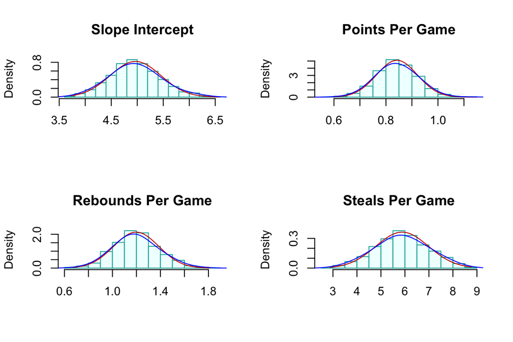

```r
for (i in 1:B){
  bootc.id = sample(1:smpl.n, smpl.n, replace = TRUE) # fit final model to the bootstrap sample
  Bootstrap_Model.btc = lm (MP ~ PTS + TRB + STL, data = Reduced_Playoff_Data2[bootc.id,])
  coef.mtrx[i,] = coef(Bootstrap_Model.btc)    # extract coefs from bootstrap regression model
}

boot.hist = function(cmtrx, bt.coef.mtrx, var.id, var.nm){
  ## bt.coef.mtrx = matrix for storing bootstrap estimates of coefficients
  ## var.id = variable ID (1, 2, ..., k+1)
  ## var.nm = variable name on the hist title, must be the string in the double quotes
  ## coefficient matrix of the final model
  ## Bootstrap sampling distribution of the estimated coefficients
  x1.1 = seq(min(bt.coef.mtrx[,var.id]), max(bt.coef.mtrx[,var.id]), length=300 )
  y1.1 = dnorm(x1.1, mean(bt.coef.mtrx[,var.id]), sd(bt.coef.mtrx[,var.id]))
  # height of the histogram - use it to make a nice-looking histogram.
  highestbar = max(hist(bt.coef.mtrx[,var.id], plot = FALSE)$density)
  ylimit = max(c(y1.1,highestbar))
  hist(bt.coef.mtrx[,var.id], probability = TRUE, main = var.nm, xlab="",
       col = "azure1",ylim=c(0,ylimit), border="lightseagreen")
  lines(x = x1.1, y = y1.1, col = "red3")
  lines(density(bt.coef.mtrx[,var.id], adjust=2), col="blue")
  #legend("topright", c(""))
}
  par(mfrow=c(2,2))  # histograms of bootstrap coefs
boot.hist(bt.coef.mtrx=coef.mtrx, var.id=1, var.nm ="Slope Intercept" )
boot.hist(bt.coef.mtrx=coef.mtrx, var.id=2, var.nm ="Points Per Game" )
boot.hist(bt.coef.mtrx=coef.mtrx, var.id=3, var.nm ="Rebounds Per Game" )
boot.hist(bt.coef.mtrx=coef.mtrx, var.id=4, var.nm ="Steals Per Game" )
```

```r
num.p = dim(coef.mtrx)[2]  # number of parameters
btc.ci = NULL
btc.wd = NULL
for (i in 1:num.p){
  lci.025 = round(quantile(coef.mtrx[, i], 0.025, type = 2),8)
  uci.975 = round(quantile(coef.mtrx[, i],0.975, type = 2 ),8)
  btc.wd[i] =  uci.975 - lci.025
  btc.ci[i] = paste("[", round(lci.025,4),", ", round(uci.975,4),"]")
 }
#as.data.frame(btc.ci)
Rounded_btc.wd = round(btc.wd,4)

cmtrx = summary(Bootstrap_Model)$coef

kable(as.data.frame(cbind(formatC(cmtrx,4,format="f"), btc.ci.95=btc.ci, Rounded_btc.wd)),
      caption = "Bootstrap Cases Regression Coefficient Matrix, 95% CI")
```

Bootstrap Cases Regression Coefficient Matrix, 95% CI

|  | Estimate | Std. Error | t value | Pr(>\|t\|) | btc.ci.95 | Rounded_btc.wd |
| --- | --- | --- | --- | --- | --- | --- |
| (Intercept) | 5.0115 | 0.5169 | 9.6947 | 0.0000 | [ 4.0371 , 6.0342 ] | 1.9971 |
| PTS | 0.8390 | 0.0658 | 12.7463 | 0.0000 | [ 0.6894 , 0.9928 ] | 0.3034 |
| TRB | 1.1951 | 0.1446 | 8.2637 | 0.0000 | [ 0.8464 , 1.5828 ] | 0.7364 |
| STL | 5.8298 | 0.8891 | 6.5572 | 0.0000 | [ 3.7215 , 8.0458 ] | 4.3244 |

### 3.1.1 Bootstrap Cases Summary

Next, we look at our 95% confidence intervals (btc.ci.95). We can see that each interval captures the range of values that our original regression coefficient plus or minus its given standard error would be equal to. This means that there is no contradiction between our model and its bootstrap sampling distribution.

## 3.2 Bootstrap Approach 2 - Bootstrap Residuals

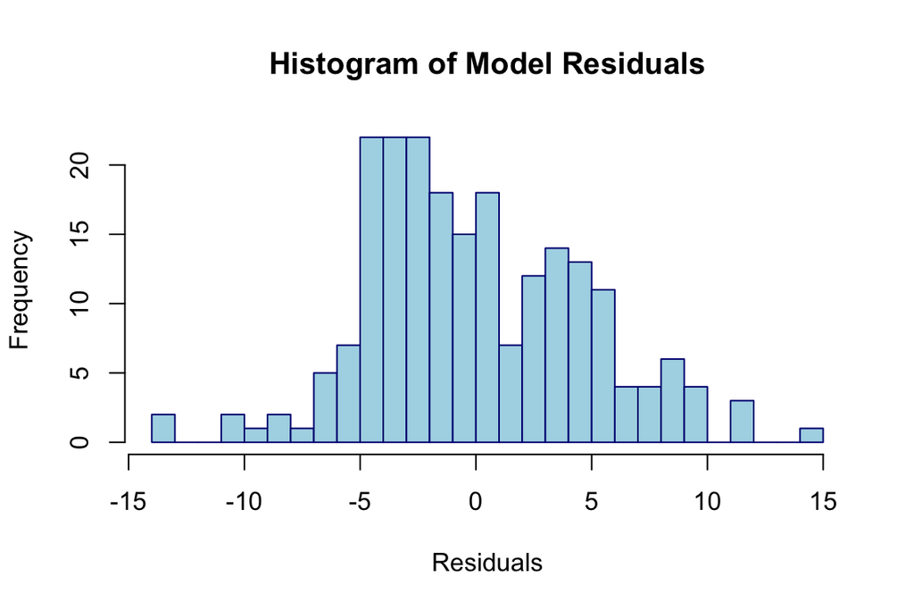

```r
hist(sort(Bootstrap_Model$residuals),n=40,
     xlab="Residuals",
     col = "lightblue",
     border="navy",
     main = "Histogram of Model Residuals")
```

```r
invisible(mean(Bootstrap_Model$residuals))

Bootstrap_Model = lm (MP ~ PTS + TRB + STL, data = Reduced_Playoff_Data2)
model.resid = Bootstrap_Model$residuals
```

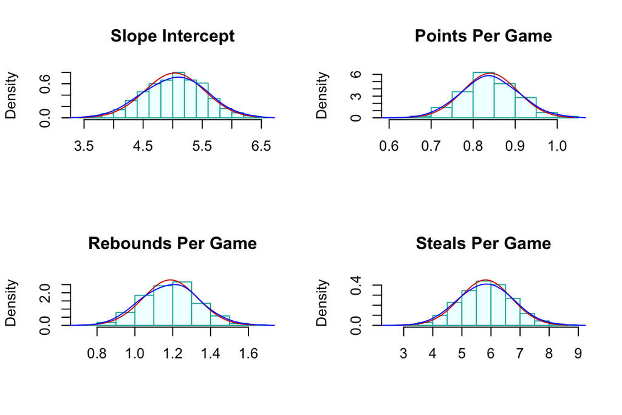

```r
C=1500
num.p = dim(model.matrix(Bootstrap_Model))[2]   # number of parameters
samp.n = dim(model.matrix(Bootstrap_Model))[1]  # sample size
btr.mtrx = matrix(rep(0,6*B), ncol=num.p) # zero matrix to store boot coefs
for (i in 1:C){
  ## Bootstrap response values
  bt.Bootstrap_Model = Bootstrap_Model$fitted.values +
        sample(Bootstrap_Model$residuals, samp.n, replace = TRUE)  # bootstrap residuals
  # replace PriceUnitArea with bootstrap log price
  Reduced_Playoff_Data2$bt.Bootstrap_Model =  bt.Bootstrap_Model   #  send the boot response to the data
  btr.model = lm(bt.Bootstrap_Model ~ PTS + TRB + STL, data = Reduced_Playoff_Data2)
  btr.mtrx[i,]=btr.model$coefficients
}

boot.hist = function(bt.coef.mtrx, var.id, var.nm){
  ## bt.coef.mtrx = matrix for storing bootstrap estimates of coefficients
  ## var.id = variable ID (1, 2, ..., k+1)
  ## var.nm = variable name on the hist title, must be the string in the double quotes
  ## Bootstrap sampling distribution of the estimated coefficients
  x1.1 <- seq(min(bt.coef.mtrx[,var.id]), max(bt.coef.mtrx[,var.id]), length=300 )
  y1.1 <- dnorm(x1.1, mean(bt.coef.mtrx[,var.id]), sd(bt.coef.mtrx[,var.id]))
  # height of the histogram - use it to make a nice-looking histogram.
  highestbar = max(hist(bt.coef.mtrx[,var.id], plot = FALSE)$density)
  ylimit <- max(c(y1.1,highestbar))
  hist(bt.coef.mtrx[,var.id], probability = TRUE, main = var.nm, xlab="",
       col = "azure1",ylim=c(0,ylimit), border="lightseagreen")
  lines(x = x1.1, y = y1.1, col = "red3")       # normal density curve
  lines(density(bt.coef.mtrx[,var.id], adjust=2), col="blue")    # loess curve
}
par(mfrow=c(2,2))  # histograms of bootstrap coefs
boot.hist(bt.coef.mtrx=btr.mtrx, var.id=1, var.nm ="Slope Intercept" )
boot.hist(bt.coef.mtrx=btr.mtrx, var.id=2, var.nm ="Points Per Game" )
boot.hist(bt.coef.mtrx=btr.mtrx, var.id=3, var.nm ="Rebounds Per Game" )
boot.hist(bt.coef.mtrx=btr.mtrx, var.id=4, var.nm ="Steals Per Game" )
```

```r
num.p = dim(coef.mtrx)[2]  # number of parameters
btr.ci = NULL
btr.wd = NULL
for (i in 1:num.p){
  lci.025 = round(quantile(btr.mtrx[, i], 0.025, type = 2),8)
  uci.975 = round(quantile(btr.mtrx[, i],0.975, type = 2 ),8)
  btr.wd[i] = uci.975 - lci.025
  btr.ci[i] = paste("[", round(lci.025,4),", ", round(uci.975,4),"]")
}

Rounded_btr.wd = round(btr.wd,4)
kable(as.data.frame(cbind(formatC(cmtrx,4,format="f"), btr.ci.95=btr.ci, Rounded_btr.wd)),
      caption = "Bootstrap Residual Regression Coefficient Matrix, 95% CI")
```

Bootstrap Residual Regression Coefficient Matrix, 95% CI

|  | Estimate | Std. Error | t value | Pr(>\|t\|) | btr.ci.95 | Rounded_btr.wd |
| --- | --- | --- | --- | --- | --- | --- |
| (Intercept) | 5.0115 | 0.5169 | 9.6947 | 0.0000 | [ 4.0389 , 6.0412 ] | 2.0023 |
| PTS | 0.8390 | 0.0658 | 12.7463 | 0.0000 | [ 0.7148 , 0.975 ] | 0.2602 |
| TRB | 1.1951 | 0.1446 | 8.2637 | 0.0000 | [ 0.9104 , 1.4664 ] | 0.556 |
| STL | 5.8298 | 0.8891 | 6.5572 | 0.0000 | [ 4.1143 , 7.5571 ] | 3.4429 |

### 3.2.1 Bootstrap Residuals Summary

We can see from our model residual histogram that our residuals are not quite normally distributed, as there is a visible slight rightward skew, yet the calculated mean of the residuals is extremely close to zero (~7.4<sup>-17</sup>), so we proceed with caution.

Lastly, we take a look at the 95% confidence intervals (btr.ci.95) created for our regression coefficients. Once again, all of our confidence intervals via the bootstrap method are within the range of our original regression-calculated coefficients, plus or minus their given standard error. Hence the results from performing the bootstrap residuals method are in alignment with the takeaways from our simplified model that we started today’s analysis with.

# 4 Conclusion

Below we can see a summary of our model, its original regression coefficients, as well as the confidence interval metrics for its bootstrap cases and bootstrap residual distributions. Given that all three methods yielded results practically in alignment with each other, we can safely say that an NBA player’s average playing time has a strong linear relationship with his averages in points, rebounds and steals per game, with the exact degree of correlation slightly differing via the widths of said confidence intervals.

```r
Rounded_Interval_Widths = cbind(Rounded_btc.wd, Rounded_btr.wd)

kable(as.data.frame(cbind(formatC(cmtrx[,-3],4,format="f"), btc.ci.95=btc.ci,btr.ci.95=btr.ci, Rounded_Interval_Widths)),
      caption="Final Regression Coefficient Estimates: P-Values and Bootstrap CIs")
```

Final Regression Coefficient Estimates: P-Values and Bootstrap CIs

|  | Estimate | Std. Error | Pr(>\|t\|) | btc.ci.95 | btr.ci.95 | Rounded_btc.wd | Rounded_btr.wd |
| --- | --- | --- | --- | --- | --- | --- | --- |
| (Intercept) | 5.0115 | 0.5169 | 0.0000 | [ 4.0371 , 6.0342 ] | [ 4.0389 , 6.0412 ] | 1.9971 | 2.0023 |
| PTS | 0.8390 | 0.0658 | 0.0000 | [ 0.6894 , 0.9928 ] | [ 0.7148 , 0.975 ] | 0.3034 | 0.2602 |
| TRB | 1.1951 | 0.1446 | 0.0000 | [ 0.8464 , 1.5828 ] | [ 0.9104 , 1.4664 ] | 0.7364 | 0.556 |
| STL | 5.8298 | 0.8891 | 0.0000 | [ 3.7215 , 8.0458 ] | [ 4.1143 , 7.5571 ] | 4.3244 | 3.4429 |

# 5 Summary/Discussion

The findings from my analysis over the past few weeks could be valuable to NBA players as well as those deeply vested in their on-court performance such as agents and advertisers. If a player desires more playing time, it is helpful to know exactly what metrics (PTS, TRB and STL in this case) having an increase in will traditionally correlate with more playing time across the league.

For my analysis, the most recent dataset I could find was one from the 2022-2023 NBA season. Moving forward, if there was a way I could perform similar exploration on data from the most recent NBA season, that would potentially bring even *more* credibility to whatever findings resulted.

# 6 References:

Original Dataset Source: https://www.kaggle.com/datasets/vivovinco/20222023-nba-player-stats-regular

Dataset Download Link via Github: https://raw.githubusercontent.com/ChrisB2323/STA321/main/Playoff_Data.csv

My Previous Analyses:

- Relationship Between All 5 Standard Statistics and Circumstance with Playing Time https://rpubs.com/Chris_Bahm/1347436
- Relationship Between Scoring Output and Playing Time: https://rpubs.com/Chris_Bahm/1344468